# (New) Variable Importance Summary, Natural Scale

Si Cheng

2021-11-12

**Difference from last version: predictions are now transformed back to their original scale (instead of log scale) before calculating variable importance.**

## Approach 2: Changing predictor value from median

We consider an alternative approach proposed during the group meeting on Oct 11. The idea was to fix each predictor at their median (one at a time), and see how the predicted values change after increasing/decreasing them by a certain magnitude.

### UFP

We follow this approach and explore variable importance for the prediction of UFP. The model was trained with all 309 locations from the mobile monitoring data, and assessed on 350 randomly sampled cohort locations (to reduce the amount of computation, since there were originally over 20k cohort locations). We compare the predicted values when each predictor takes their 12.5%, 25%, 37.5%, 50%, 62.5%, 75%, 87.5% quantiles.

**The plots below show the average difference in predicted UFP concentration, when each predictor value changes from their 25% to 50%, 50% to 75% and 25% to 75% quantiles, respectively.**

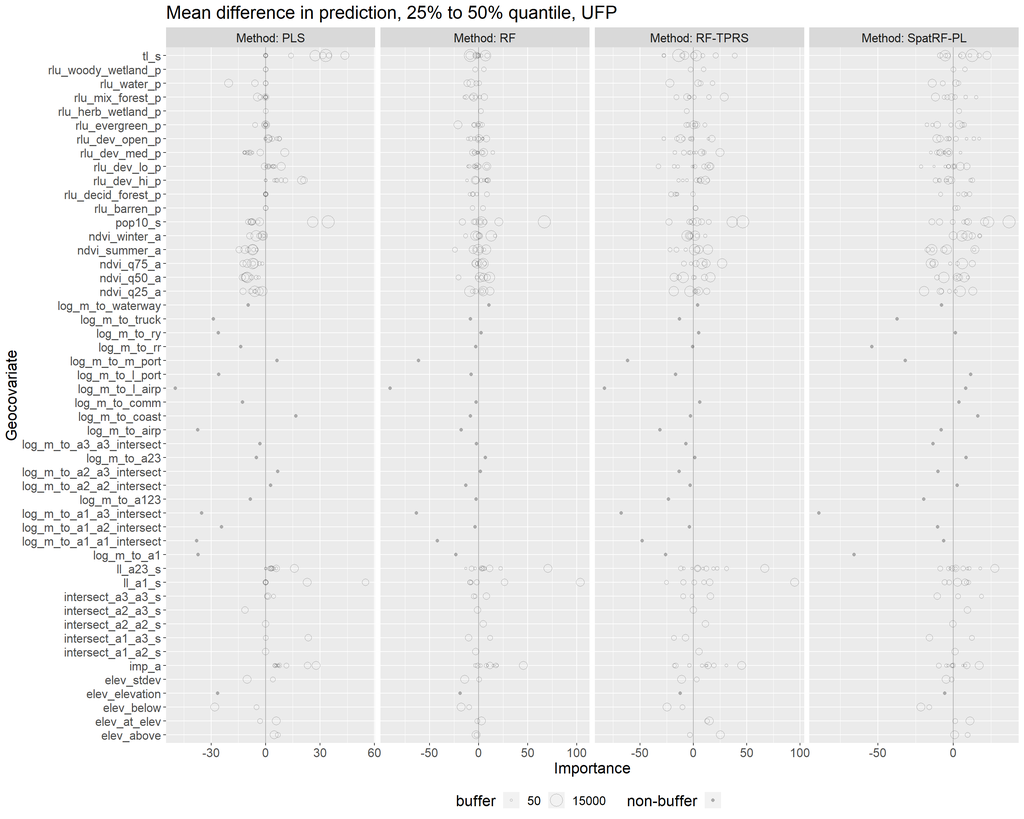

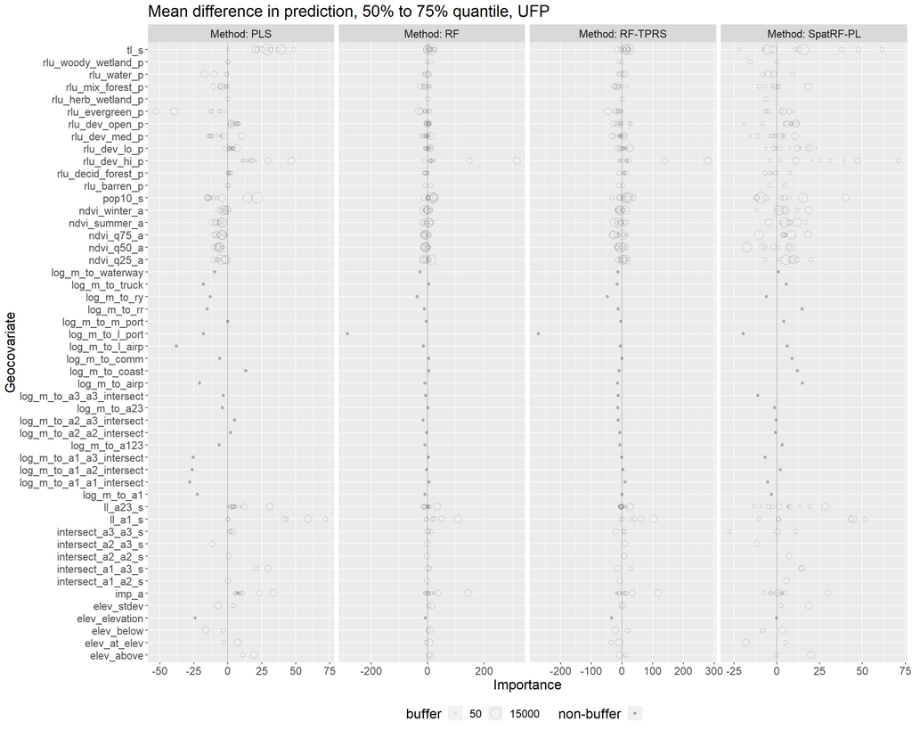

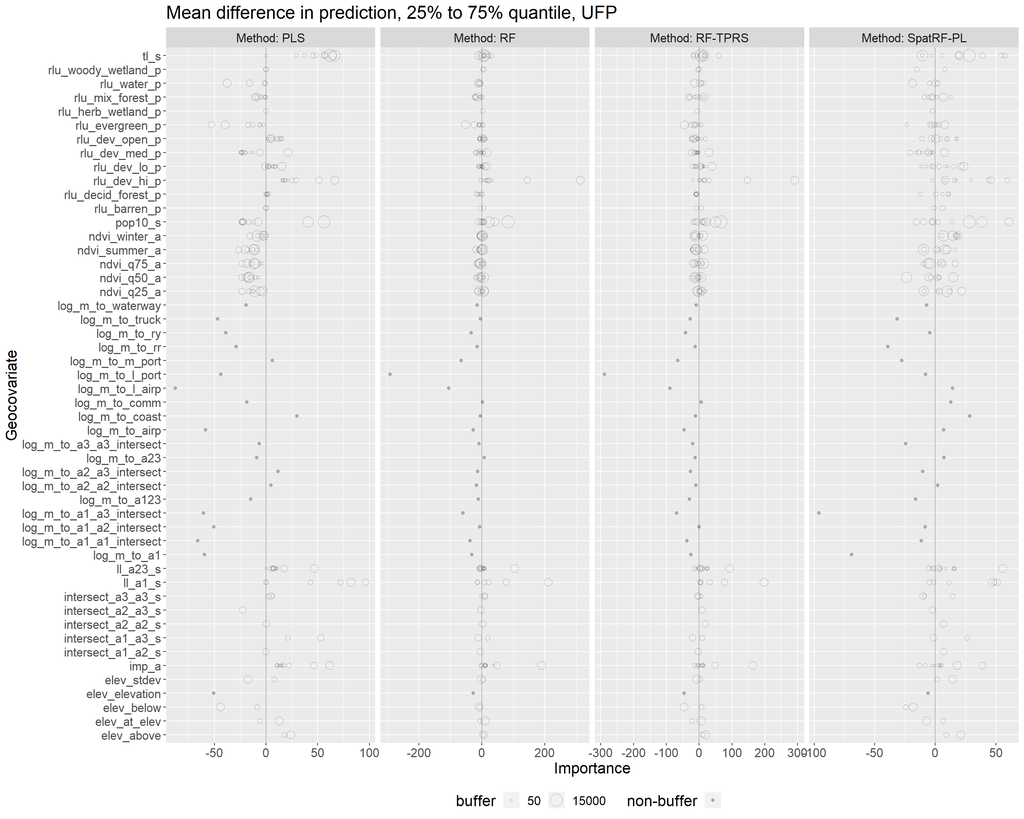

To find the set of predictors for which UK-PLS and SpatRF produced clearly different importance measures, we standardize the variable importance measures, and find the greatest differences between UK-PLS and SpatRF.

25% to 50% quantile, UFP

| PLS | SpatRF | abs(difference) | Variable |
| --- | --- | --- | --- |
| 1.803566 | -1.0564409 | 2.860007 | intersect_a1_a3_s03000 |
| 4.153232 | 0.6265257 | 3.526706 | ll_a1_s03000 |
| 2.644404 | -0.5517950 | 3.196199 | tl_s01500 |
| -3.631122 | 0.6530894 | 4.284211 | log_m_to_l_airp |
| -2.562184 | -6.2738374 | 3.711654 | log_m_to_a1_a3_intersect |

50% to 75% quantile, UFP

| PLS | SpatRF | abs(difference) | Variable |
| --- | --- | --- | --- |
| 4.332434 | -0.2707109 | 4.603145 | ll_a1_s01500 |
| 1.027138 | 4.5393162 | 3.512178 | rlu_dev_hi_p01000 |
| -3.315562 | 0.1400288 | 3.455591 | rlu_evergreen_p03000 |
| 1.730948 | -1.8316624 | 3.562611 | tl_s00400 |
| 2.314190 | -0.7023103 | 3.016501 | tl_s10000 |

25% to 75% quantile, UFP

| PLS | SpatRF | abs(difference) | Variable |
| --- | --- | --- | --- |
| 2.5816086 | -0.4464814 | 3.028090 | ll_a1_s01500 |
| 2.3739940 | -0.7549069 | 3.128901 | tl_s10000 |
| -0.2960341 | 2.9243980 | 3.220432 | pop10_s05000 |
| -3.1867060 | 0.5291951 | 3.715901 | log_m_to_l_airp |
| -2.2132313 | -5.1384899 | 2.925258 | log_m_to_a1_a3_intersect |

Summarizing in words, the predictors for which the importance differs the most are

- 25% to 50%: Distance to large airports, distance to A1-A3 intersections, length of A1 roads, length of truck routes, length of A1-A3 intersections
- 50% to 75%: Length of A1 roads, length of truck routes, highly-developed land use, evergreen forest land
- 25% to 75%: Distance to large airports, population, length of truck routes, length of A1 roads, distance to A1-A3 intersections

which are similar to what we observed on the log scale.

### BC

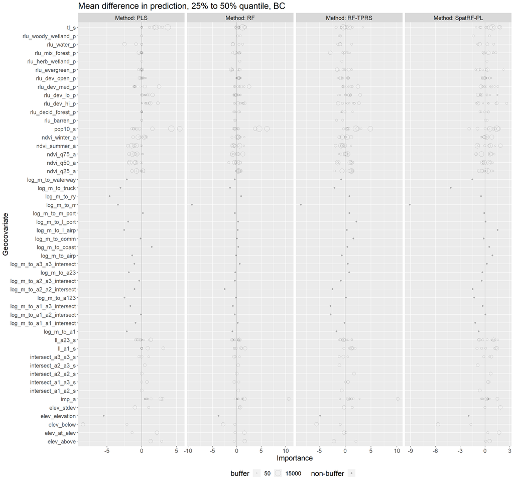

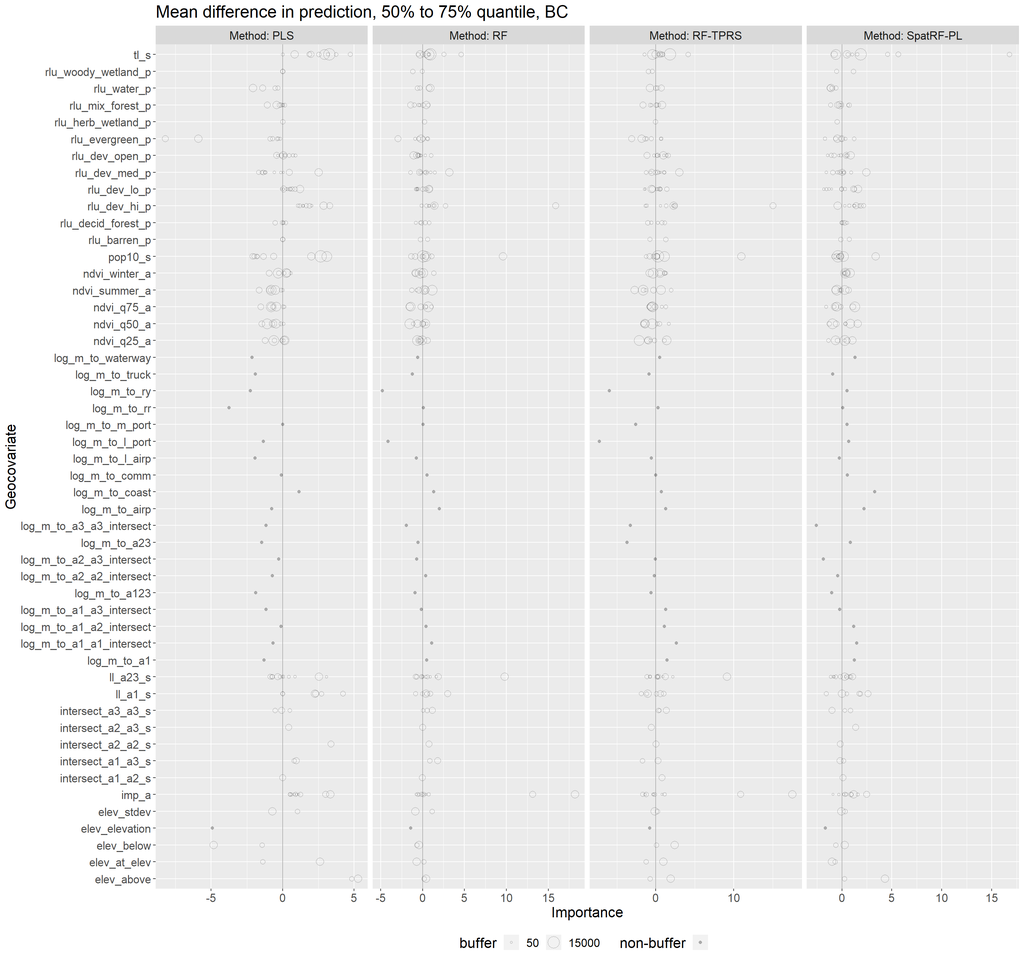

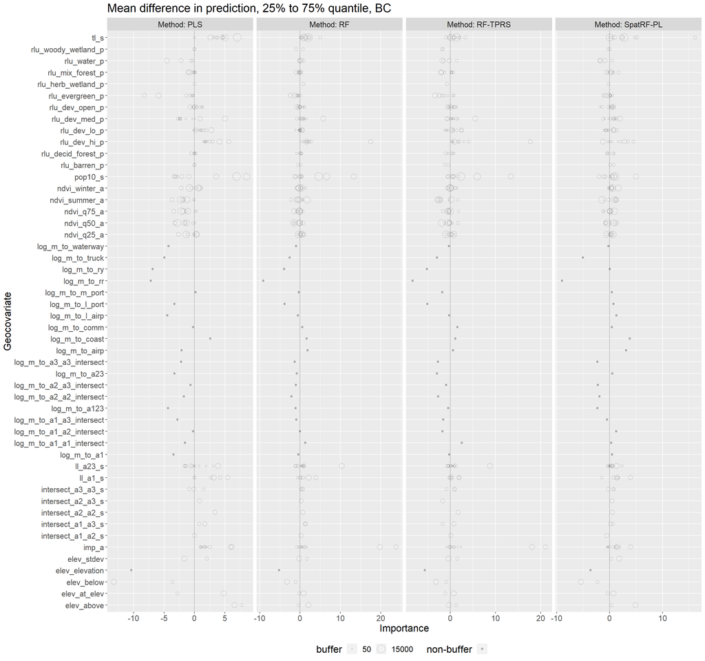

The greatest differences between UK-PLS and SpatRF:

25% to 50% quantile, BC

| PLS | SpatRF | abs(difference) | Variable |
| --- | --- | --- | --- |
| 2.075203 | -0.4755578 | 2.550761 | tl_s01500 |
| 3.740936 | 0.4137293 | 3.327207 | pop10_s10000 |
| -1.636303 | 1.2175483 | 2.853851 | log_m_to_l_airp |
| -3.030114 | -0.4595924 | 2.570522 | log_m_to_ry |
| -2.232566 | -7.6250237 | 5.392457 | log_m_to_rr |

50% to 75% quantile, BC

| PLS | SpatRF | abs(difference) | Variable |
| --- | --- | --- | --- |
| 2.711823 | -0.0462520 | 2.758075 | elev_1k_above |
| -2.805469 | -0.0296569 | 2.775812 | elev_5k_below |
| -4.747027 | -0.1999869 | 4.547040 | rlu_evergreen_p03000 |
| -3.416596 | -0.4668937 | 2.949702 | rlu_evergreen_p05000 |
| 1.387298 | 9.7610943 | 8.373797 | tl_s01000 |

25% to 75% quantile, BC

| PLS | SpatRF | abs(difference) | Variable |
| --- | --- | --- | --- |
| 2.565276 | -0.0250330 | 2.590309 | elev_1k_above |
| 1.370427 | -0.8140643 | 2.184491 | rlu_dev_hi_p05000 |
| 1.207473 | 7.7994915 | 6.592019 | tl_s01000 |
| 2.850176 | 0.1594720 | 2.690704 | pop10_s10000 |
| -2.382385 | -4.6433786 | 2.260993 | log_m_to_rr |

Summarizing in words, the predictors for which the importance differs the most are

- 25% to 50%: Distance to railroads, population, distance to large airports, distance to rail yards, length of truck routes
- 50% to 75%: length of truck routes, evergreen forest land, relative elevation
- 25% to 75%: length of truck routes, population, relative elevation, distance to railroads, highly-developed land use

which are also similar to our findings on the log scale.